# Ford GoBike: Bike rides data in San Francisco Bay Area: 2019

## Investigation Overview:

#### In this investigation, I would like to know the number of bike rides in Bay area, in relation to months, day amd time of day, average biking time and its distribution among subscribers and customers.

## Dataset Overview:

#### The dataset has 2506983 observations, with attributes like station names, ride timestamp as start time and end time, duration and types of users (customer/subscriber). Few obseravations were considered as outliers, and were removed during exploration.

# Rides distribution according to:

## 1: Month of year and day of week

#### It can be seen that the highest number of rides is during July, followed by March and least are in December (most probably because of cold weather and shorter day light duration).

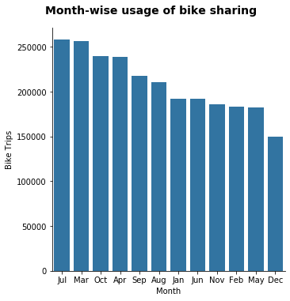

```python
#Monthwise
base_color = sb.color_palette()[0]

g = sb.catplot(data=df, x='month', kind='count', color = base_color, order = months)
g.set_axis_labels("Month", "Bike Trips")
g.fig.suptitle('Month-wise usage of bike sharing', y=1.05, fontsize=14, fontweight='semibold');
```

#### While for weeks, it can be noticed that the number of rides are high on weekdays and considerably less on weekends.

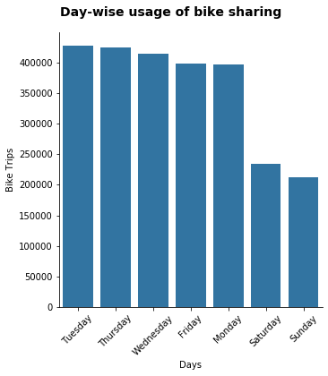

```python
#Daywise
g = sb.catplot(data=df, x='day', kind='count', color = base_color, order = days)
g.set_axis_labels("Days", "Bike Trips")
plt.xticks(rotation = 45)
g.fig.suptitle('Day-wise usage of bike sharing', y=1.05, fontsize=14, fontweight='semibold');
```

## 2 Number of rides as per hours of the day

#### This shows that the bikes are in high demand during morning time (7-10 hours) and evening (16-19 hours). Tis is mostly because most of the rides use bikes for comuuting to and from office.

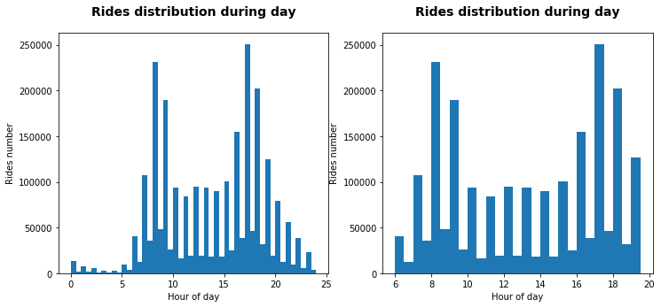

```python
#this will tell about the time when bikes demand was highest.
import numpy as np
plt.figure(figsize = [12,5])

plt.subplot(1,2,1)
bin_edges = np.arange(0, 24.5, 0.5)
plt.ylabel("Rides number")
plt.xlabel("Hour of day")
plt.title("Rides distribution during day", y=1.05, fontsize=14, fontweight='semibold')
plt.hist(data = df, x = time_int, bins = bin_edges);

plt.subplot(1,2,2)
bin_edges = np.arange(6, 20, 0.5)
plt.ylabel("Rides number")
plt.xlabel("Hour of day")
plt.title("Rides distribution during day", y=1.05, fontsize=14, fontweight='semibold')
plt.hist(data = df, x = time_int, bins = bin_edges);
```

# Average biking duration

#### When we just check average ride duration for the whole data, we see there are few outliers, and removing them gives a better ideas that the average biking duration is around 10 min, with highest being around 28 min. If histogram is checked, then its clear that it is right skewed, with most bikers duration falling in range of 5-10 min, and then decreasing with increasing time.

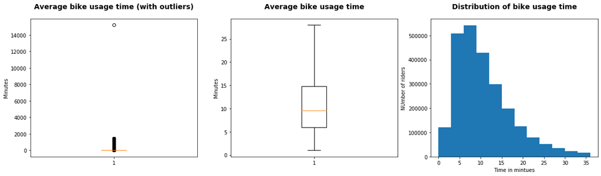

```python
#bins = np.arange(0, df.duration_min.max()+50, 50)
plt.figure(figsize=(20,5))
plt.subplot(131)
plt.title("Average bike usage time (with outliers)", y=1.05, fontsize=14, fontweight='semibold')
plt.ylabel("Minutes")
plt.boxplot(data = df, x = 'duration_min');

plt.subplot(132)
plt.title("Average bike usage time", y=1.05, fontsize=14, fontweight='semibold')
plt.ylabel("Minutes")
plt.boxplot(data = df, x = 'duration_min', showfliers = False);

plt.subplot(133)
bin_edges = np.arange(0, 36+3, 3)
plt.title("Distribution of bike usage time", y=1.05, fontsize=14, fontweight='semibold')
plt.ylabel("NUmber of riders")
plt.xlabel("Time in mintues")
plt.hist(data = df, x = 'duration_min', bins = bin_edges);
```

# Top routes for biking: best 20

#### Most famous route, or the highest number of riders go from San Francisco Ferry Building (Harry Bridges Plaza) to The Embarcadero at Sansome St, and vice versa. This contributes to 5091 trip and then again 3204 in opposite direction.

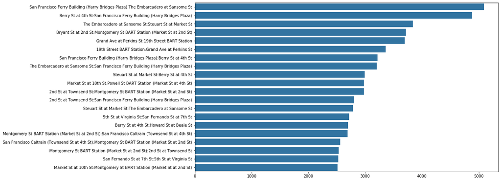

```python
plt.figure(figsize = [14,8])
sb.barplot(y = top_20_stations_list, x = top_20_stations_count, orient = "h", color = base_color)
```

# Types of users

#### We see that the users are more as subscribers, and they contribute to 80% of total users. Only 1/5th of the total users are customers.

```python
sorted_counts = df['user_type'].value_counts()
sizes = sorted_counts.values
total_users = df.shape[0]
proportion = []
for n in sizes:
    proportion.append(round(n*100/total_users, 2))
proportion
```

```
[80.62, 19.38]
```

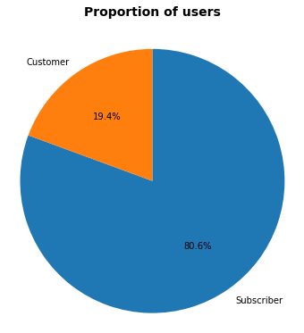

```python
plt.figure(figsize=(10,6))
plt.pie(proportion, labels = sorted_counts.index, startangle = 90,
        counterclock = False, autopct = '%1.1f%%');
plt.axis('square')
plt.title("Proportion of users", y=1.05, fontsize=14, fontweight='semibold');
```

# Biking time according to months and days

#### If we check the average ride duration in months, then we notice that the average bike duration is high in September and June and Lowest in February. The duration in days is very contrasting from the number of rides, while average number of rides were hgh during weekdays, the average ride duration is high during weekends.

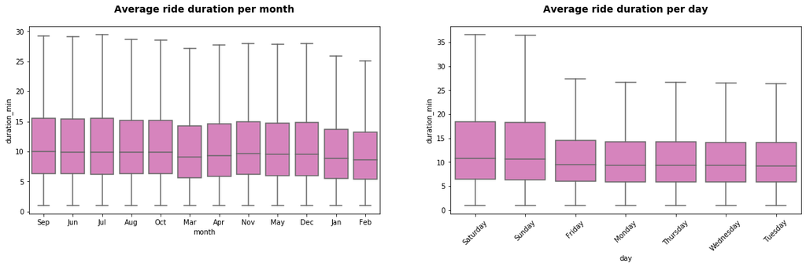

```python
plt.figure(figsize=(20,5))
base_color = sb.color_palette()[6]
plt.subplot(121)
sb.boxplot(data = df, x = 'month', y = 'duration_min', color = base_color,showfliers = False, order = duration_month.index.tolist());
plt.title("Average ride duration per month", y=1.05, fontsize=14, fontweight='semibold')


plt.subplot(122)
sb.boxplot(data = df, x = 'day', y = 'duration_min', color = base_color,showfliers = False, order = duration_day.index.tolist());
plt.xticks(rotation = 45)
plt.title("Average ride duration per day", y=1.05, fontsize=14, fontweight='semibold')
```

# Distribution of user at different hours of day/ month

#### This shows that on an average, most rides are subscribers only with highest usage during offcie hours only, that is between 7am to 11 am, and then back time between 4pm and 7pm. For months, it can be noticed that the number of riders are almost same in December, but for the rest of the months, the gap is huge.

```python
#lets devide day in 4 parts as day_time
#peak_1 = 7-11
#low_1 = 11-16
#peak_2 = 16-19
#low_2 = 19-7
df.head(1)
day_time = []
#time_int was a list prepared before, with times as integer.
for time in time_int:
    if time>7 and time<=11:
        day_time.append('peak_1')
    elif time>11 and time<=16:
        day_time.append('low_1')
    elif time>16 and time<=19:
        day_time.append('peak_2')
    else:
        day_time.append('low_2')

len(day_time)

df['day_time'] = day_time
df.head(1)
df.shape
```

```
(2506982, 20)
```

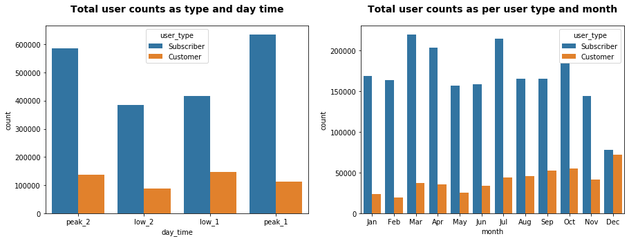

```python
plt.figure(figsize = (15,5))

plt.subplot(1,2,1)
sb.countplot(data = df, x = 'day_time', hue = 'user_type');
plt.title("Total user counts as type and day time", y=1.05, fontsize=14, fontweight='semibold')

plt.subplot(1,2,2)
sb.countplot(data = df, x = 'month', hue = 'user_type');
plt.title("Total user counts as per user type and month", y=1.05, fontsize=14, fontweight='semibold')
```

# Bike rides duration according to users and months of year/ Days of week

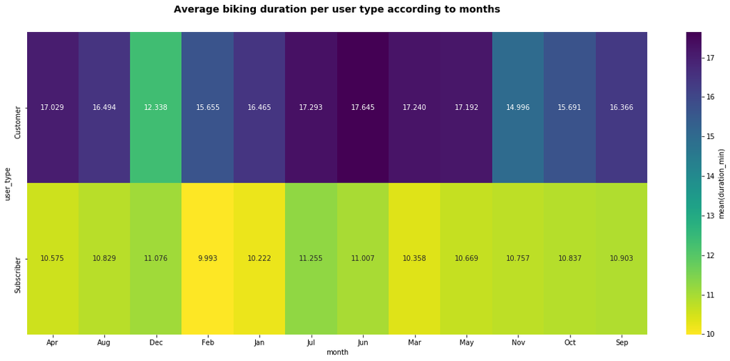

```python
# now lets make above heat map again with filtered data
plt.figure (figsize=(20, 8))
cat_means = df_filtered.groupby(['month', 'user_type']).mean()['duration_min']
cat_means = cat_means.reset_index(name = 'duration_avg')
cat_means = cat_means.pivot(index = 'user_type', columns = 'month',
                            values = 'duration_avg')
plt.title("Average biking duration per user type according to months", y=1.05, fontsize=14, fontweight='semibold')
sb.heatmap(cat_means, annot = True, fmt = '.3f',
           cbar_kws = {'label' : 'mean(duration_min)'}, cmap = 'viridis_r');
```

#### In case of days, the duration was very high for customers on weekends, as 18.838 on Saturday and 18.850 on Sunday. For subscribers, it did not make any huge difference.

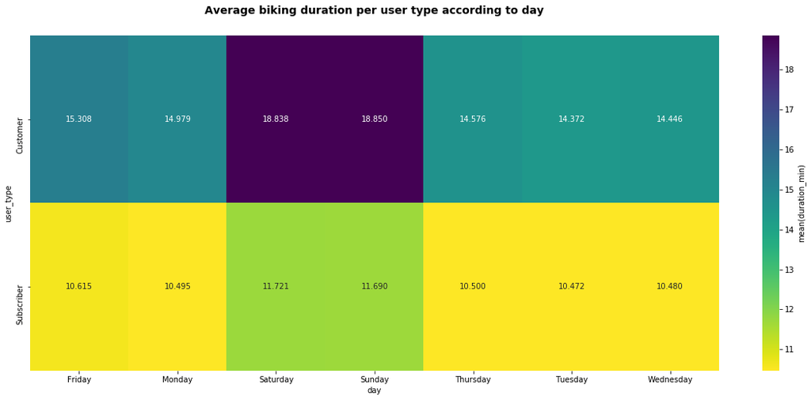

```python
plt.figure (figsize=(20, 8))
cat_means = df_filtered.groupby(['day', 'user_type']).mean()['duration_min']
cat_means = cat_means.reset_index(name = 'duration_avg')
cat_means = cat_means.pivot(index = 'user_type', columns = 'day',
                            values = 'duration_avg')
plt.title("Average biking duration per user type according to day", y=1.05, fontsize=14, fontweight='semibold')
sb.heatmap(cat_means, annot = True, fmt = '.3f',
           cbar_kws = {'label' : 'mean(duration_min)'}, cmap = 'viridis_r');
```